# Simulation and profiling

## str function

str provides information on a object. Very useful for displaying large list. It as an alternative to summary

## Simulation - Generating random numbers

- rnorm: generate random Normal variartes with a given mean and standard deviation (prefix r for random)
- dnorm: evaluate the Normal probability density (with given mean/SD) at a point (or vector of points) (prefix d for density)
- pnorm: evaluate the cumulative distribution function of a Normal distribution (prefix p for cumulative)
- qnorm: evaluate de quartile function (prefix q for quantile)
- rpois: generate random Poisson variates with a given rate

```r
# example
#set.seed(1) # important to set the random number generator seed to generate the same set of random number again
#
#dnorm(x, mean = 0, sd = 1, log = FALSE)
#pnorm(q, mean = 0, sd = 1, lower.tail = TRUE, log.p = FALSE) #if lower.tail = FALSE, then the upper tail of the distribution is evaluated
#rnorm(n, mean = 0, sd = 1) #n, number of random variables that you want to generate

# if [PHI] is the cumulative distribution function for a standard Normal distribution, then pnomr(q) = [PHI](q) and qnorm(p) = [PHI]exp(-1)(p)
```

## Simulation - Simulating a linear model

```r
# example
set.seed(20)
x <- rnorm(100) # default mean = 0, sd = 1
e <- rnorm(100, 0, 2)
y <- 0.5 + 2 * x + e
summary(y)
```

```
##    Min. 1st Qu.  Median    Mean 3rd Qu.    Max.
## -6.4084 -1.5402  0.6789  0.6893  2.9303  6.5052
```

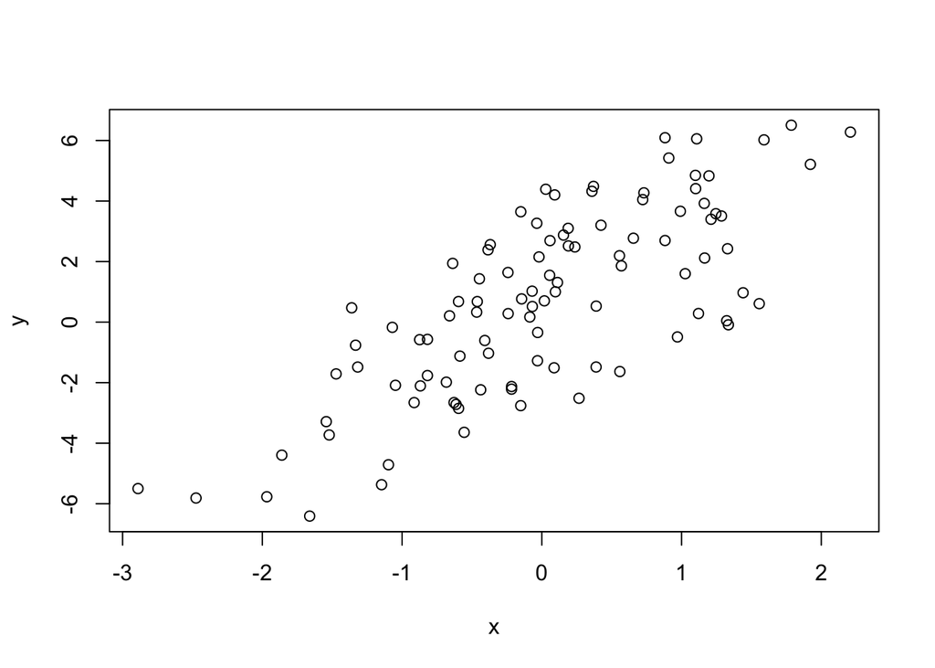

```r
plot(x,y)
```

```r
# other example if x is binary

set.seed(10)
x <- rbinom(100, 1, 0.5)
x
```

```
##   [1] 1 0 0 1 0 0 0 0 1 0 1 1 0 1 0 0 0 0 0 1 1 1 1 0 0 1 1 0 1 0 1 0 0 1 0 1 1
##  [38] 1 1 1 0 0 0 1 0 0 0 0 0 1 0 1 0 0 0 1 0 0 0 1 0 0 0 0 1 1 1 0 0 0 0 1 1 1
##  [75] 0 1 0 1 0 0 1 0 0 1 0 0 1 0 0 0 0 1 1 1 0 1 0 1 1 0
```

```r
e <- rnorm(100, 0, 2)
y <- 0.5 + 2 * x + e
summary(y)
```

```
##    Min. 1st Qu.  Median    Mean 3rd Qu.    Max.
## -3.4936 -0.1409  1.5767  1.4322  2.8397  6.9410
```

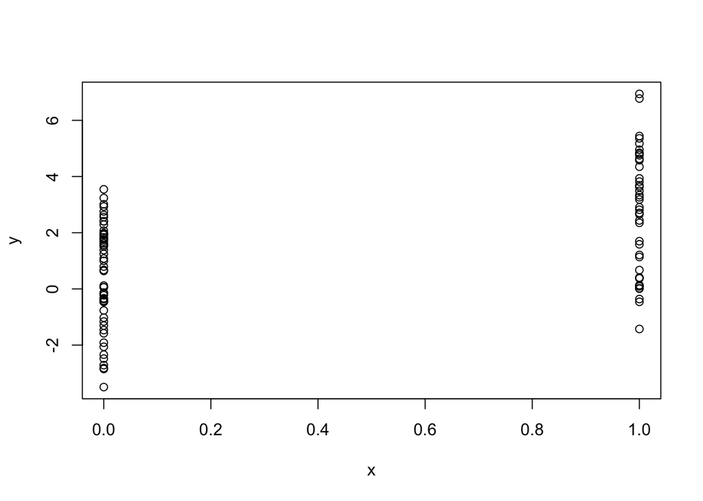

```r
plot(x,y)
```

```r
# example :simulate from a Poisson model

set.seed(1)
x <- rnorm(100)
log.mu <- 0.5 + 0.3 * x
y <- rpois(100, exp(log.mu))
summary(y)
```

```
##    Min. 1st Qu.  Median    Mean 3rd Qu.    Max.
##    0.00    1.00    1.00    1.55    2.00    6.00
```

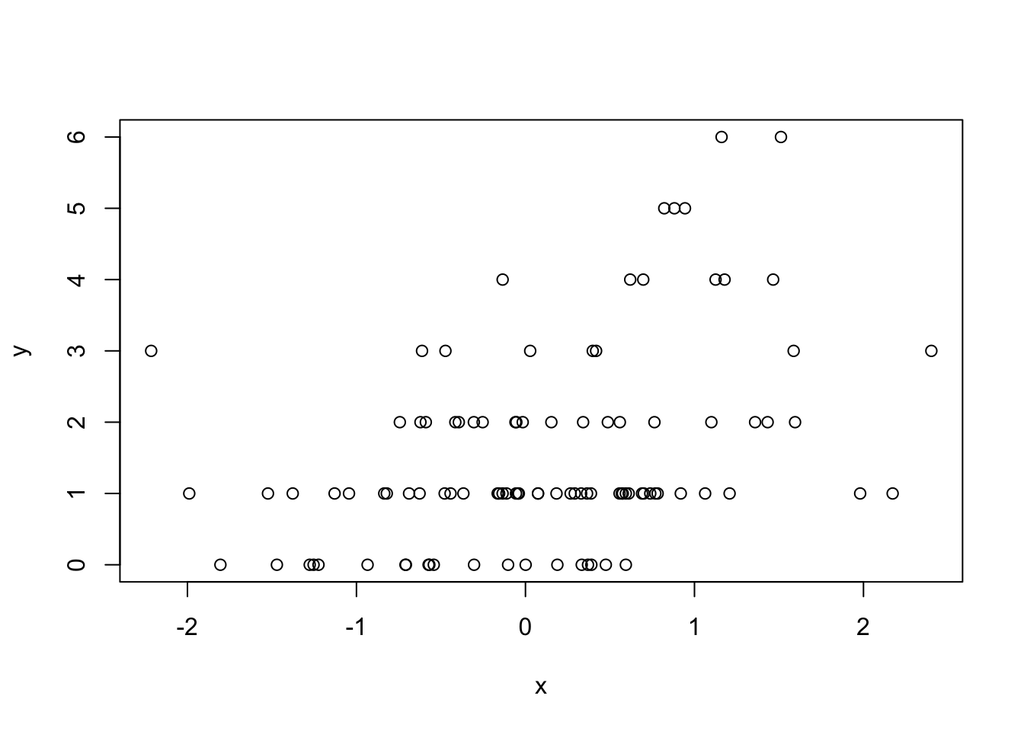

```r
plot(x,y)
```

## Simulation - Random sampling

The sample function draws randomly from a specified set of (scalar) objects allowing you to sample from arbitrary distributions.

```r
set.seed(1)
sample(1:10, 4)
```

```
## [1] 9 4 7 1
```

```r
sample(1:10, 4)
```

```
## [1] 2 7 3 6
```

```r
sample(letters, 5)
```

```
## [1] "r" "s" "a" "u" "w"
```

```r
sample(1:10) ## permutation
```

```
##  [1] 10  6  9  2  1  5  8  4  3  7
```

```r
sample(1:10)
```

```
##  [1]  5 10  2  8  6  1  4  3  9  7
```

```r
sample(1:10, replace = TRUE)
```

```
##  [1]  3  6 10 10  6  4  4 10  9  7
```

## R Profiler

**Why is my code so slow?**

- Profiling is a systematic way to examine how much time is spend in different parts of a program
- Useful when trying to optimize your code
- Often code runs fine once, but what if you have to put it in a loop for 1,000 iterations? Is it still fast enough?
- Profiling is better than guessing

We should forget about small efficiencies, say about 97% of the time: premature optimization is the root of all evil (Donald Knuth). –> Design first, then optimize

**Using system.time()**

It takes a R expression as input (can be wrapped in currl braces) and returns the amount of time taken to evaluate the expression. Two different type of time: user time (amount of time that is charged to CPUs) and elapse time (the one that we experience)

```r
system.time(readLines("https://www.google.com"))
```

```
##    user  system elapsed
##   0.016   0.002   0.268
```

```r
# example 2
system.time({
  n <- 1000
  r <- numeric(n)
  for(i in 1:n) {
    x <- rnorm(n)
    r[i] <- mean(x)
  }

})
```

```
##    user  system elapsed
##   0.206   0.003   0.209
```

**Using Rprof()**

R must be compiled with profiler support (but it is usually the case). The summaryRprof() function summarizes the output from Rprof().

DO NOT use system.time() and Rprof() together or you will be sad!

The summaryProf() function tabulates the R profiler output and calculates how much time is spent in which function. There are two methods for normalizing the data:

- by.total: divides the time spent in each function by the total run time
- by.sell: does the same but first substracts out time spent in functions above in the call stack